# Project_3

저자

Choi Pro

[figure not shown]

아래는 R을 이용한 데이터 전처리 예제입니다. 문제와 답만 있습니다. 풀이 과정을 코드로 제출하세요. 제출 결과에 따라 다음 과정의 Project 3 난이도 조정이 됩니다.

*전압에 따른 패널 휘도 측정 결과* 데이터 셋 다운로드

### 1. 휘도 균일도(Luminance Uniformity) 정의

- 최대-최소법: (Lmax - Lmin)/(Lmax + Lmin) × 100%
- 표준편차법: σ/μ × 100% (CV, Coefficient of Variation)
- 9점 균일도: 9개 측정점의 최대/최소 비율
- VESA 규격: (1 - (Lmax - Lmin)/Lavg) × 100%

### 2. 목표 사양

- Target 휘도: 500 ± 55 nit (445 ~ 555 nit)
- 균일도 기준: CV ≤ 10%
- 9점 균일도: ≤ 1.2 (max/min ratio)

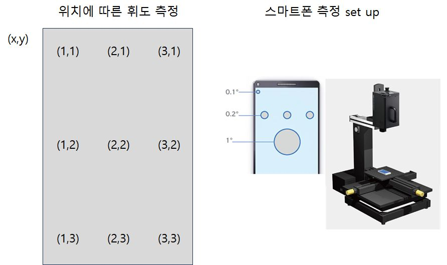

## 이론적 배경

OLED(Organic Light Emitting Diode) 디스플레이의 휘도는 주로 세 가지 핵심 전압에 의해 제어됩니다:

1. ELVDD (Positive Supply Voltage)
   - 패널의 양극(anode)에 인가되는 양의 전압
   - 일반적으로 약 5V 설정
2. ELVSS (Negative Supply Voltage)
   - 패널의 음극(cathode)에 인가되는 음의 전압
   - 보통 -1.5V 미만으로 설정
   - ELVSS 전압이 더 낮아질수록(음의 방향) 휘도가 증가
   - ELVSS 전압이 0V에 가까워질수록 휘도가 감소
3. Data 전압
   - 각 픽셀의 밝기를 제어
   - OLED 구동 트랜지스터의 게이트에 인가

## ELVSS 전압 레벨과 휘도 관계

ELVSS는 일반적으로 DC 전압으로 공급되며, 약 -1.5V 미만의 값을 가집니다[3].

**ELVSS 값의 변화에 따른 PMOS 휘도 영향:**

- ELVSS 값이 작아질 경우 (더 음의 방향으로): 휘도가 높아집니다. PMOS 트랜지스터의 소스-드레인 전압차가 증가하여 더 많은 전류가 흐르게 되고, 이는 OLED의 발광 강도를 증가시킵니다.
- ELVSS 값이 커질 경우 (0V에 가까워질 때): 휘도가 낮아집니다. PMOS 트랜지스터의 소스-드레인 전압차가 감소하여 전류가 줄어들고, 이로 인해 OLED의 발광 강도가 감소합니다.

PMOS 트랜지스터를 사용하는 OLED 픽셀 회로에서는 VGS가 VG-ELVDD로 결정되기 때문에, ELVSS의 변화가 직접적으로 트랜지스터의 동작에 영향을 미치며, 이는 결과적으로 OLED의 휘도를 조절하게 됩니다

## 측정 방법

첨부된 이미지에서 보이는 것처럼, 패널은 3x3 매트릭스로 구성되어 있으며, 각 위치에서 휘도를 측정합니다. 측정은 특수 제작된 휘도계를 사용하여 수행됩니다.

# 난이도 하: ELVSS에 따른 휘도 Trend를 볼 수 있도록 점, 선 그래프를 그려라.

- 데이터 로드
- ELVSS 에 따른 평균 휘도, 표준편차 계산
- ggplot으로 point, line 그래프 그리기
- x, y, title 에 적절한 단어 넣기

**코드**

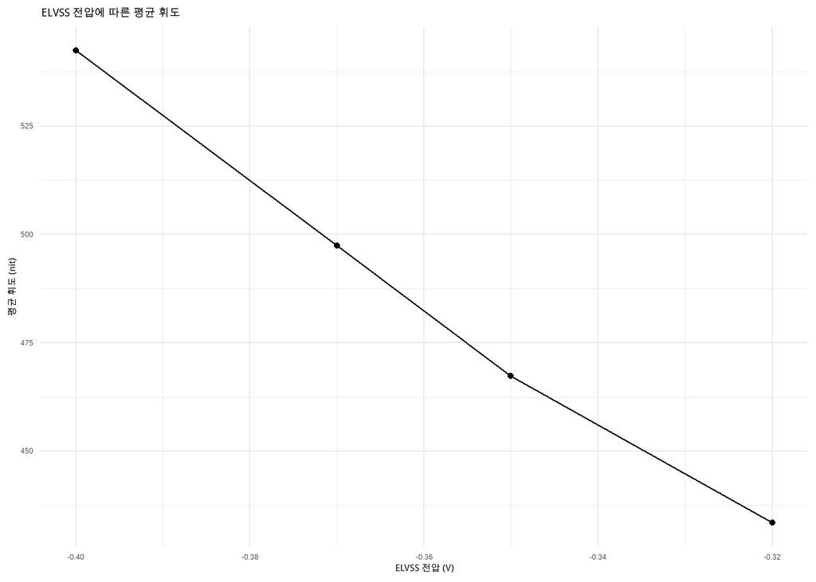

```r
# 필요한 패키지 로드
library(tidyverse)
library(showtext)
showtext.auto()

# 데이터 로드
df <- read.csv("./data/luminance_measurement.csv")

# ELVSS 전압별 평균 휘도 계산
elvss_summary <- df %>%
  group_by(ELVSS) %>%
  summarise(mean_luminance = mean(luminance),
            sd_luminance = sd(luminance))

# 기본 시각화
p1 <- ggplot(elvss_summary, aes(x = ELVSS, y = mean_luminance)) +
  geom_point() +
  geom_line() +
  labs(title = "ELVSS 전압에 따른 평균 휘도",
       x = "ELVSS 전압 (V)",
       y = "평균 휘도 (nit)") +
  theme_minimal()

p1
```

# 난이도 중: ELVSS별 휘도 MAP 그래프를 그려라.

- geom_tile 을 이용하여 luminance에 따른 색을 다르게 하는 MAP을 그린다.
- facet_wrap(~ELVSS, labeller = label_both) 로 ELVSS 에 따른 MAP을 그린다.
- scale_fill_viridis_c() 를 사용하여 색을 조정한다.

**코드**

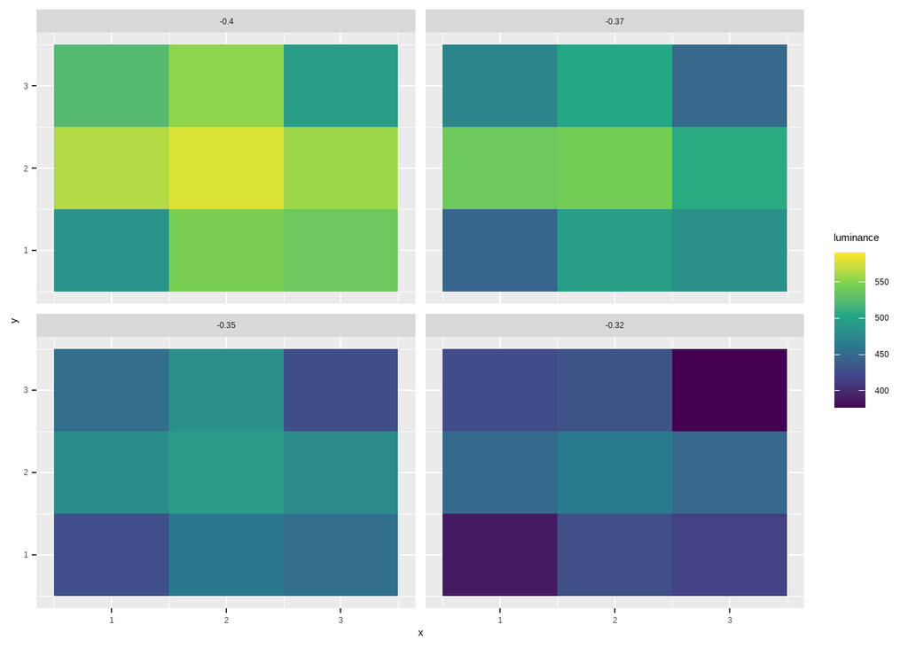

```r
# 위치별 휘도 히트맵

p2 <- df |> ggplot(aes(x=x, y=y, fill=luminance))+
  geom_tile()+
  facet_wrap(~ELVSS,)+
  scale_fill_viridis_c()

p2
```

# 난이도 상: target 휘도를 맞추기 위해 ELVSS 를 선정하라. 그 전압에서 uniformity는 얼마인가?

- x축을 ELVSS 전압, y축을 luminace로 하는 boxplot 을 그려라.
- target 휘도 및 상한치, 하한치 (500 ± 55 nit) 에 geom_hline으로 선을 그린다.
- scale_fill_viridis_d() 를 사용하여 색을 조정한다
- labs 를 이용하여 title, subtitle, x, y 축 라벨을 작성한다.
- target 휘도를 맞추기 위해서는 ELVSS 전압을 선정한다. (-0.37V)
- 아래 uniformity 정의에 맞게 새로운 변수를 만든 후 bar chart를 그려라.
- bar chart 에 uniformity 값을 geom_text로 넣어라.

$$\text{Uniformity}(\%) = \frac{L_{max} - L_{min}}{L_{max} + L_{min}} \times 100$$

**코드**

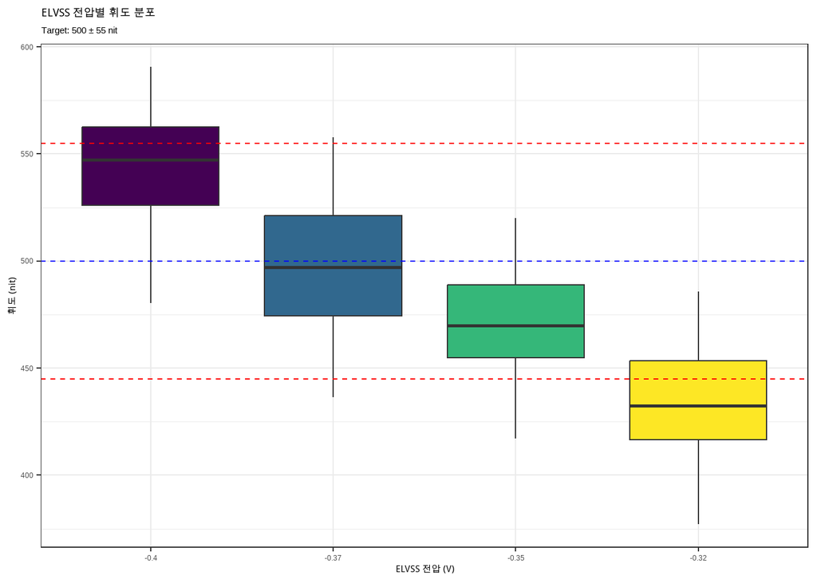

```r
# ELVSS 전압별, 위치별 휘도 변화 분석

 df %>%
  mutate(ELVSS = factor(ELVSS)) %>%  # ELVSS를 factor로 변환
  ggplot(aes(x = ELVSS, y = luminance, fill = ELVSS)) +
  geom_boxplot() +
  geom_hline(yintercept = 500, col = "blue", linetype = "dashed") +
  geom_hline(yintercept = c(445, 555), col = "red", linetype = "dashed") +
  labs(title = "ELVSS 전압별 휘도 분포",
       subtitle = "Target: 500 ± 55 nit",
       x = "ELVSS 전압 (V)",
       y = "휘도 (nit)") +
  theme_bw() +
  scale_fill_viridis_d() +
  theme(legend.position = "none")
```

**코드**

[figure not shown]

```r
df %>%
  group_by(ELVSS) %>%
  summarise(
    uniformity = (max(luminance) - min(luminance))/ ((max(luminance) + min(luminance)))*100) |>
  mutate(ELVSS = factor(ELVSS)) %>%
  ggplot(aes(x = ELVSS, y = uniformity, fill = ELVSS)) +
  geom_bar(stat = "identity", position = "dodge") +
  geom_text(aes(label = sprintf("%.1f%%", uniformity)),
            position = position_dodge(0.9),
            vjust = -0.5) +
  labs(title = "패널별 ELVSS 전압에 따른 휘도 균일도(CV)",
       x = "ELVSS 전압 (V)",
       y = "uniformity (%)") +
  theme_bw()
```